# 第13回 対応分析で、クロス表のずれを読む

映画のジャンルと年代

# 導入

## 第12回は気候、今日は映画

① 今日のデータ●○

- 第12回は、数の列（気温・降水量）を少ない軸にまとめた
- 今日のデータは、数ではなく区分（年代とジャンル）
- 区分×区分で数えた表を、地図にする

## 映画の評価サイトの公開データ

① 今日のデータ●●

- ミネソタ大学のGroupLensが、映画の評価サイトMovieLensのデータを研究用に公開している
- 今日は、その小さな版（ml-latest-small）の映画の一覧を使う
- 再配布は認められていないので、ノートの中で取得元から取ってくる

## 年代で、好まれるジャンルは違う？

② 場面●○

- 1930年代の映画と、2010年代の映画では、作られたジャンルが違いそう
- 白黒の時代はロマンス？ 今はアクション？
- 印象ではなく、数えた表から読みたい

## 決めたいこと

② 場面●●

- 年代ごとに、どのジャンルが多いか、少ないか
- 本数の多い年代・ジャンルに引きずられずに、割合の偏りを読みたい
- 年代とジャンルの関係を、1枚の地図にしたい

## 手元のデータ

③ 手元のデータ●○

- MovieLensの映画の一覧（Harper & Konstan, 2015）。9,742本
- 1行が1本の映画。題名に公開年、ジャンルの列には「|」で区切った複数のジャンル
- 答えの列は無い。年代とジャンルの組を数える

## データをのぞく

③ 手元のデータ●●

|  | movieId | title | genres |
| --- | --- | --- | --- |
| 0 | 1 | Toy Story (1995) | Adventure\|Animation\|Children\|Comedy\|Fantasy |
| 1 | 2 | Jumanji (1995) | Adventure\|Children\|Fantasy |
| 2 | 3 | Grumpier Old Men (1995) | Comedy\|Romance |

- 1本目のトイ・ストーリーは、5つのジャンルを持つ

## 最後に出す答え

④ 今日の問い●○

- 年代ごとに、どのジャンルが割合として多いか
- 年代とジャンルの関係は、1枚の地図にするとどう見えるか

## 今日の問い

④ 今日の問い●●

映画のジャンルの好まれ方は、年代でどう違うか。それを1枚の地図にできるか？

## もう1つのねらい：文字列を分ける

⑤ もう1つのねらい●

- 文字列を区切って分け、1行に詰まった複数の値を、数えられる形に直せるようになる
- 「|」で区切ったジャンルを分け、1行を何行にもする
- お手本ごとに、コードを1行ずつ読み、変数の中身を見る

# 今日の一周

## 結果だけで一度通す

⑥ 今日の一周●○○○○○○

- まず、今日の解析を、結果だけで一度通して見る
- コードはあとで。どんな結論になるかを先に知っておく

## 一周①：年代×ジャンルの表

⑥ 今日の一周●●○○○○○

| ジャンル 年代 | アクション | 冒険 | コメディ | 犯罪 | ドラマ | ファンタジー |
| --- | --- | --- | --- | --- | --- | --- |
| 1930 | 8 | 13 | 53 | 15 | 74 | 8 |
| 1940 | 8 | 13 | 55 | 29 | 118 | 11 |
| 1950 | 15 | 30 | 67 | 29 | 146 | 11 |
| 1960 | 56 | 65 | 132 | 43 | 192 | 25 |
| 1970 | 103 | 71 | 155 | 70 | 225 | 31 |
| 1980 | 227 | 170 | 492 | 124 | 439 | 106 |
| 1990 | 392 | 239 | 890 | 264 | 1038 | 149 |
| 2000 | 549 | 363 | 1135 | 404 | 1365 | 252 |
| 2010 | 464 | 292 | 758 | 218 | 743 | 178 |

- えっ、表の合計は18,544本。でも映画は9,162本しかない（ここでは6ジャンルだけ）

## 一周②：偏りがなければ何本？

⑥ 今日の一周●●●○○○○

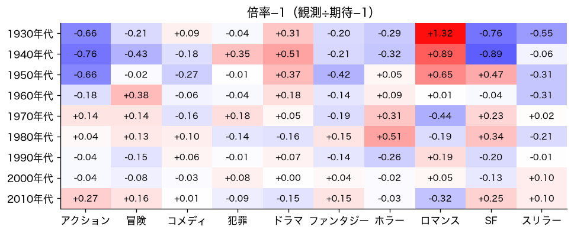

- 年代の本数とジャンルの本数から、偏りがなければ何本かを出し、何倍かを見る

## 一周③：ずれを測る

⑥ 今日の一周●●●●○○○

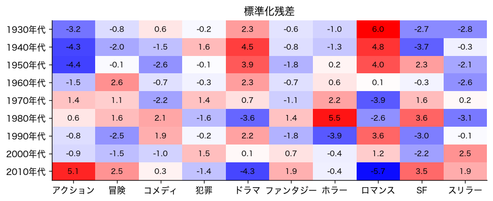

- 赤は多すぎ、青は少なすぎ。1930年代のロマンス、2010年代のアクション

## 一周④：1枚の地図

⑥ 今日の一周●●●●●○○

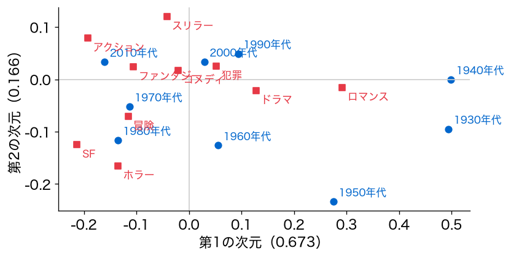

- 横軸は古い↔︎新しい。えっ、本数がいちばん多い2000年代は、真ん中にいる

## 一周⑤：倍率で確かめる

⑥ 今日の一周●●●●●●○

- 1930年代：ロマンス2.32倍、ドラマ1.31倍
- 1980年代：ホラー1.51倍、SF1.34倍
- 2010年代：アクション1.27倍、SF1.25倍

## 一周は5つの段

⑥ 今日の一周●●●●●●●

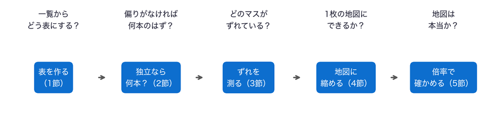

- このあと、5つの段の中身を、1つずつ開けていく

## 問いとやること①②

⑦ 問いとやること●○

- 表を作る：一覧からどう表にする？ → 題名から年代を取り出し、ジャンルを分けて、年代×ジャンルの表を作る（1節）
- 独立なら何本？：偏りがなければ何本のはず？ → 期待度数を出し、観測と比べた倍率を見る（2節）

## 問いとやること③④⑤

⑦ 問いとやること●●

- ずれを測る：どのマスがずれている？ → 標準化残差を色の表で見る（3節）
- 地図に縮める：1枚の地図にできるか？ → 残差の表を特異値分解し、年代とジャンルを同じ地図に置く（4節）
- 倍率で確かめる：地図は本当か？ → 地図の近さを倍率の表で確かめ、年代ごとに1文にする（5節）

## 今日の進め方

⑧ 今日の進め方●

- 段ごとに、スライドで聞く → ノートで実行して答える
- 段の終わりの「ノートへ」で、予想を書き、1か所を替えて実行し、予想と比べる
- 予想は外れてかまわない

# 0. 準備

## まずは道具を呼び出す

- 0節は、道具を呼び出すだけ。ノートで1節と続けて実行する

# 1. 一覧から、どう表にする？

## 段1：表を作る

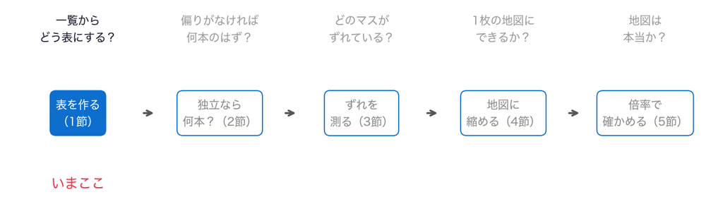

- 問い：映画1本ごとの一覧から、年代×ジャンルの表をどう作るか

## お手本：取ってきて展開する

1節 ① 取ってくる●○

```python
import os
import shutil
import urllib.request
WORK = '/content'   # Colab の作業場所
URL = ('https://files.grouplens.org/datasets/movielens/'
       'ml-latest-small.zip')
if not os.path.exists(f'{WORK}/ml-latest-small'):
    urllib.request.urlretrieve(URL, f'{WORK}/ml.zip')
    shutil.unpack_archive(f'{WORK}/ml.zip', WORK)
print(sorted(os.listdir(f'{WORK}/ml-latest-small')))
```

```
['README.txt', 'links.csv', 'movies.csv', 'ratings.csv', 'tags.csv']
```

## 1行ずつ：取ってきて展開する

1節 ① 取ってくる●●

```python
import os
import shutil
import urllib.request
WORK = '/content'   # Colab の作業場所
URL = ('https://files.grouplens.org/datasets/movielens/'
       'ml-latest-small.zip')
if not os.path.exists(f'{WORK}/ml-latest-small'):
    urllib.request.urlretrieve(URL, f'{WORK}/ml.zip')
    shutil.unpack_archive(f'{WORK}/ml.zip', WORK)
print(sorted(os.listdir(f'{WORK}/ml-latest-small')))
```

- `import`の行：フォルダ（`os`）・zip（`shutil`）・URL（`urllib`）を扱う道具。`WORK`と`URL`の行：作業場所と取得元
- `if`の行：まだ展開したフォルダが無いときだけ、取ってきて（`urlretrieve`）、展開する（`unpack_archive`）
- `print`の行：フォルダの中の5つのファイル。使うのは`movies.csv`だけ

## お手本：映画の一覧を読む

1節 ② 読む●

```python
movies = pd.read_csv(f'{WORK}/ml-latest-small/movies.csv')
print(len(movies))
movies.head(3)
```

```
9742
```

- 1行目：一覧を読む。2行目：9,742本。3行目：先頭3本

## 題名から公開年を取り出す

1節 ③ 年代●○○

- 公開年は、題名の最後の「(1995)」の中にある
- 文字列の決まった形（かっこの中の4けたの数）を探して、取り出す
- その形を書く文字の並びを、正規表現という。今日は1つだけ使う

## お手本：公開年と年代

1節 ③ 年代●●○

```python
m = movies.copy()
m['年'] = m['title'].str.extract(r'\((\d{4})\)\s*$')[0].astype(float)
m = m.dropna(subset=['年'])
m['年代'] = (m['年'] // 10 * 10).astype(int)
m = m[m['年代'] >= 1930]
print(len(m))
```

```
9682
```

## 1行ずつ：公開年と年代

1節 ③ 年代●●●

```python
m = movies.copy()
m['年'] = m['title'].str.extract(r'\((\d{4})\)\s*$')[0].astype(float)
m = m.dropna(subset=['年'])
m['年代'] = (m['年'] // 10 * 10).astype(int)
m = m[m['年代'] >= 1930]
print(len(m))
```

- 2行目：題名の最後の「(4けたの数)」を取り出し（`str.extract`）、数にする。中身は読み飛ばしてよい
- 3行目：公開年が書かれていない映画を外す。4行目：10で割って切り捨て、10を掛けて年代にする
- 5・6行目：1930年代より前は本数が少ないので外す。残りは9,682本

## 1マスに複数のジャンル

1節 ④ 分ける●○○○○○○

- ジャンルの列には「Adventure|Comedy」のように、複数のジャンルが「|」で区切って入っている
- このままでは、ジャンルごとに数えられない
- 「|」で分けて、1本の映画を、ジャンルの数だけの行にする

## 文字列を分ける：最小の例

1節 ④ 分ける●●○○○○○

```python
s = 'Adventure|Comedy|Romance'
print(s.split('|'))
print(len(s.split('|')))
```

```
['Adventure', 'Comedy', 'Romance']
3
```

- 1行目：「|」で区切った文字列。2行目：`split('|')`で分けると、リストになる。3行目：3つ

## 1行を、何行にもする

1節 ④ 分ける●●●○○○○

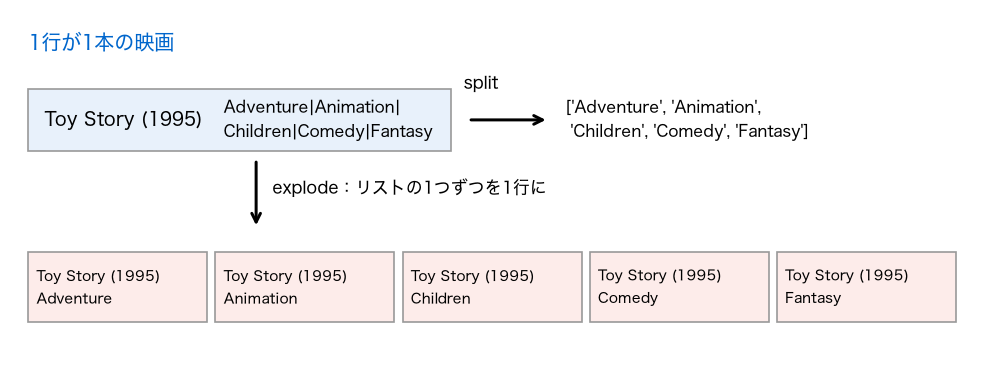

- 列の1つずつを分けてリストにし（`str.split`）、リストの1つずつを1行にする（`explode`）

## お手本：ジャンルを分ける

1節 ④ 分ける●●●●○○○

```python
g = m.copy()
g['ジャンル'] = g['genres'].str.split('|')
g = g.explode('ジャンル')
print(len(m), len(g))
g[['title', 'ジャンル']].head(5)
```

```
9682 21972
```

## 1行ずつ：ジャンルを分ける

1節 ④ 分ける●●●●●○○

```python
g = m.copy()
g['ジャンル'] = g['genres'].str.split('|')
g = g.explode('ジャンル')
print(len(m), len(g))
g[['title', 'ジャンル']].head(5)
```

- 2行目：ジャンルの列を、1本ずつ「|」で分けてリストにする（`str.split`は列のすべての行に`split`を当てる）
- 3行目：リストの1つずつを1行にする（`explode`）。題名や年代は、同じ値が写される
- 4・5行目：行の数は9,682から21,972に増えた。先頭5行を見る

## 中身を見る：トイ・ストーリー

1節 ④ 分ける●●●●●●○

```python
g[g['title'] == 'Toy Story (1995)'][['title', '年代', 'ジャンル']]
```

|  | title | 年代 | ジャンル |
| --- | --- | --- | --- |
| 0 | Toy Story (1995) | 1990 | Adventure |
| 0 | Toy Story (1995) | 1990 | Animation |
| 0 | Toy Story (1995) | 1990 | Children |
| 0 | Toy Story (1995) | 1990 | Comedy |
| 0 | Toy Story (1995) | 1990 | Fantasy |

- 1本の映画が、5つのジャンルの5行になった。年代は5行とも同じ

## 重要概念：文字列を分ける

1節 ④ 分ける●●●●●●●

1つのマスに詰めた複数の値は、区切りの文字で分け（split）、1つずつを1行にする（explode）。そうすると、数えられる形になる。

## お手本：年代×ジャンルの表

1節 ⑤ 表●○

```python
top = g['ジャンル'].value_counts().index[:10]
g = g[g['ジャンル'].isin(top)]
O = pd.crosstab(g['年代'], g['ジャンル'])
print(O.shape, O.values.sum(), g['movieId'].nunique())
```

```
(9, 10) 18544 9162
```

## 1行ずつ：年代×ジャンルの表

1節 ⑤ 表●●

```python
top = g['ジャンル'].value_counts().index[:10]
g = g[g['ジャンル'].isin(top)]
O = pd.crosstab(g['年代'], g['ジャンル'])
print(O.shape, O.values.sum(), g['movieId'].nunique())
```

- 1・2行目：本数の多い上位10ジャンルを選び、その行だけ残す（`isin`）
- 3行目：年代×ジャンルの組ごとに数える（`pd.crosstab`、第7回）。観測度数の表`O`
- 4行目：形、表の合計、映画の本数（`nunique`は重なりを除いた数）

## えっ、合計が映画より多い

1節 ⑥ 重なり●○

- 表の合計は18,544。でも、映画は9,162本
- 7割の映画が、2つ以上のジャンルを持ち、重ねて数えられている
- 表の1つの数は、1本の別の映画、とは限らない

## 年代ごとの合計

1節 ⑥ 重なり●●

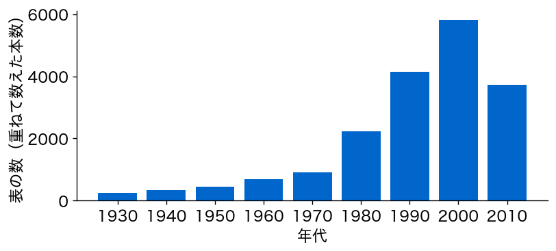

- 新しい年代ほど、本数が多い。2000年代がいちばん多い

## 結果を見る前に、予想を書く

1節 ⑦ 予想●

- 1930年代のロマンスは、全体と比べて多いだろうか
- 予想を書いてから、2節へ進む

## TODO①：ジャンルの数を替える

1節 ⑧ ジャンルの数●

```python
# TODO: 10 を 6 に替えて実行する
top_x = g_all['ジャンル'].value_counts().index[:10]
g_x = g_all[g_all['ジャンル'].isin(top_x)]
O_x = pd.crosstab(g_x['年代'], g_x['ジャンル'])
print(O_x.shape, O_x.values.sum())
```

- `g_all`は、上位を選ぶ前のジャンルを分けた表。予想：6ジャンルにすると、表の合計はどれだけ減るか

## ここまでで分かったこと

1節 ⑨ 分かったこと●

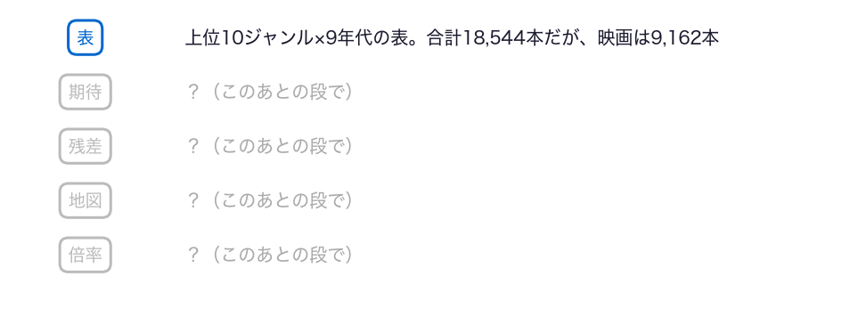

- まだ分からないのは、偏りがなければ各マスが何本になるはずか

## ノートへ：0・1節

1節 10 ノートへ●

- 0・1節のセルを上から実行し、スライドと同じ数が出るか確かめる
- 予想を書く：1930年代のロマンスは、全体と比べて多いか
- TODO①：予想を書く → `10`を`6`に替えて実行 → 予想と比べる

動画の人は、ここで一時停止。

## 答え合わせ：TODO①

1節 11 答え合わせ●

```
(9, 6) 14631
```

- 6ジャンルで14,631。少ないジャンルの4つを外しても、2割ほどしか減らない
- 上位のジャンルに、数が集まっている

# 2. 偏りがなければ何本？

## 段2：独立なら何本？

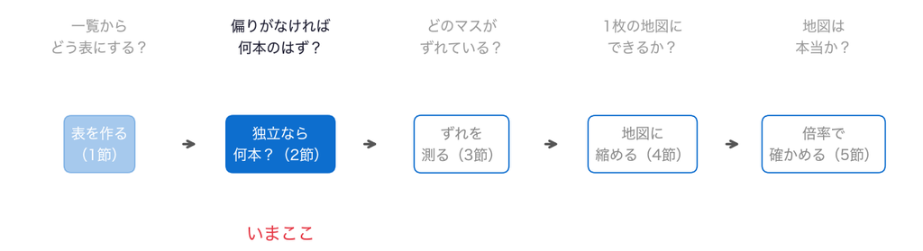

- 問い：年代とジャンルに関係がなければ、各マスは何本になるはずか

## 前の段から

2節 ① 前の段から●

- 題名から年代を取り出し、ジャンルを分けて、10ジャンル×9年代の表を作った
- 表の合計は18,544。映画は9,162本で、重ねて数えている
- 年代の本数も、ジャンルの本数もばらばら。そのまま比べられない

## 本数のままでは比べられない

2節 ② 比べ方●

- 2000年代のドラマは多い。でもそれは、2000年代の映画が多いからかもしれない
- ドラマ自体が多いジャンルでもある
- 年代の大きさとジャンルの大きさから、偏りがなければ何本かを出し、それと比べる

## 期待度数

2節 ③ 期待●○○○

年代 $i$ の合計を $n_{i\cdot}$、ジャンル $j$ の合計を $n_{\cdot j}$、全体を $n$ とする。

$$E_{ij} = \frac{n_{i\cdot} \times n_{\cdot j}}{n}$$

- 年代とジャンルが関係なければ（独立なら）、マスの数はおよそ $E_{ij}$ になる
- 年代の割合 × ジャンルの割合 × 全体

## お手本：期待度数

2節 ③ 期待●●○○

```python
n = O.values.sum()
E = np.outer(O.sum(axis=1), O.sum(axis=0)) / n
E = pd.DataFrame(E, index=O.index, columns=O.columns)
print(E.shape)
print(E.iloc[0, :3].round(1).tolist(), O.iloc[0, :3].tolist())
```

```
(9, 10)
[23.8, 16.4, 48.8] [8, 13, 53]
```

## 1行ずつ：期待度数

2節 ③ 期待●●●○

```python
n = O.values.sum()
E = np.outer(O.sum(axis=1), O.sum(axis=0)) / n
E = pd.DataFrame(E, index=O.index, columns=O.columns)
print(E.shape)
print(E.iloc[0, :3].round(1).tolist(), O.iloc[0, :3].tolist())
```

- 1・2行目：表の合計。年代の合計（9個）とジャンルの合計（10個）のすべての組を掛けて（`np.outer`）、合計で割る
- 3行目：行と列の名前を付けて、表にする
- 4・5行目：9×10の期待度数。1930年代の先頭3ジャンルの、期待と観測

## 中身を見る：np.outer

2節 ③ 期待●●●●

```python
print(np.outer([1, 2, 3], [10, 20]))
```

```
[[10 20]
 [20 40]
 [30 60]]
```

- 左の3個と右の2個の、すべての組の積を並べた3×2の表。入れ子の`for`（第9回）を1行で

## 倍率

2節 ④ 倍率●○○○○

- 観測度数 ÷ 期待度数。1より大きければ多すぎ、小さければ少なすぎ
- 年代やジャンルの大きさの違いを、取り除いた比べ方
- 2倍、0.5倍のように、言葉で言いやすい

## お手本：倍率の表

2節 ④ 倍率●●○○○

```python
ratio = O / E
print(ratio.loc[1930, 'Romance'].round(2))
print(O.loc[1930, 'Romance'], E.loc[1930, 'Romance'].round(1))
```

```
2.32
48 20.7
```

## 1行ずつ：倍率の表

2節 ④ 倍率●●●○○

```python
ratio = O / E
print(ratio.loc[1930, 'Romance'].round(2))
print(O.loc[1930, 'Romance'], E.loc[1930, 'Romance'].round(1))
```

- 1行目：マスごとに、観測÷期待（表どうしの割り算は、同じ位置どうし）
- 2行目：1930年代のロマンスの倍率（`loc`で行と列の名前を指す）
- 3行目：その観測度数と期待度数

## 1930年代のロマンスは2.32倍

2節 ④ 倍率●●●●○

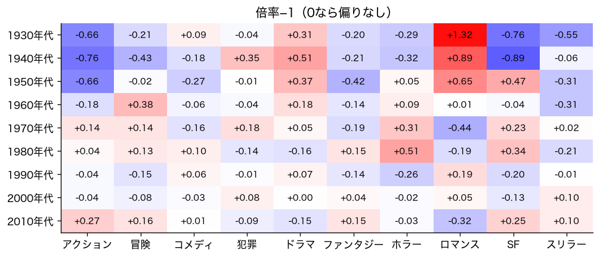

- 古い年代はロマンス・ドラマが多い。1940年代のSFは、ほとんど無い

## 重要：大きさを取り除く

2節 ④ 倍率●●●●●

本数そのままでは、年代やジャンルの大きさに引きずられる。偏りがなければ何本か（期待度数）と比べると、割合の偏りが読める。

## TODO②：見るマスを替える

2節 ⑤ マス●○

```python
# TODO: 1930 を 1940 に、'Romance' を 'Sci-Fi' に替えて実行する
print(ratio.loc[1930, 'Romance'].round(2))
print(O.loc[1930, 'Romance'])
```

- 予想：1940年代のSFは、期待と比べて何倍か

## ここまでで分かったこと

2節 ⑤ マス●●

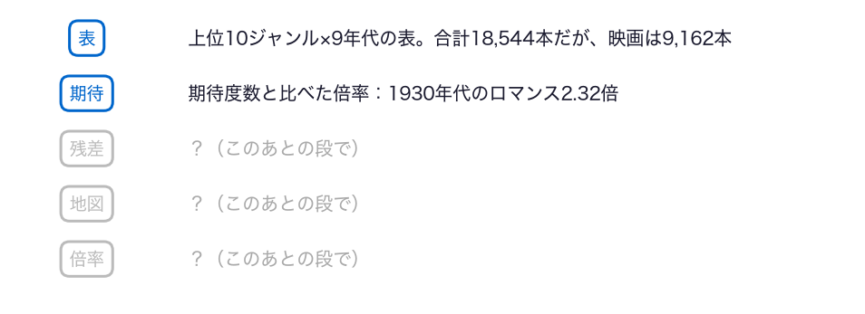

- まだ分からないのは、どのマスのずれが大きいと言えるか

## ノートへ：2節

2節 ⑥ ノートへ●

- 2節のセルを上から実行し、スライドと同じ数が出るか確かめる
- TODO②：予想を書く → `1930`を`1940`に、`'Romance'`を`'Sci-Fi'`に替えて実行 → 予想と比べる

動画の人は、ここで一時停止。

## 答え合わせ：TODO②

2節 ⑦ 答え合わせ●

```
0.11
2 17.5
```

- 1940年代のSFは0.11倍。期待17.5本に対して、2本しかない
- ただし、2本と少ない。倍率だけでは、偶然の揺れか見分けにくい

# 3. どのマスがずれている？

## 段3：ずれを測る

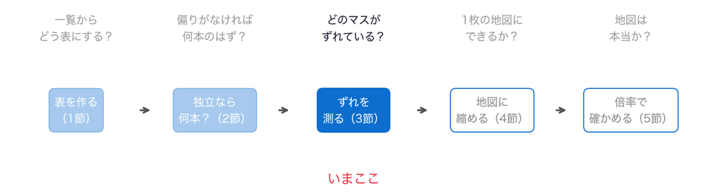

- 問い：どのマスのずれが大きいか。本数の少ないマスと、多いマスを同じ物差しで比べるには

## 前の段から

- 偏りがなければ何本か（期待度数）を出し、倍率で比べた
- 1930年代のロマンスは2.32倍、1940年代のSFは0.11倍
- でも、期待が2本のマスの3倍と、期待が500本のマスの1.2倍は、どちらが大きなずれか

## 標準化残差

3節 ① 残差●○○

$$r_{ij} = \frac{O_{ij} - E_{ij}}{\sqrt{E_{ij}}}$$

- 観測と期待の差を、期待の平方根で割る。数え上げの揺れの大きさで割った、ずれの大きさ
- 偏りがなければ、多くのマスで−2〜2くらいに収まる

## お手本：標準化残差

3節 ① 残差●●○

```python
R = (O - E) / np.sqrt(E)
print(R.loc[1930, 'Romance'].round(1), R.loc[1940, 'Sci-Fi'].round(1))
print((R.values ** 2).sum().round(1))
```

```
6.0 -3.7
548.4
```

## 1行ずつ：標準化残差

3節 ① 残差●●●

```python
R = (O - E) / np.sqrt(E)
print(R.loc[1930, 'Romance'].round(1), R.loc[1940, 'Sci-Fi'].round(1))
print((R.values ** 2).sum().round(1))
```

- 1行目：マスごとに、（観測−期待）÷√期待
- 2行目：1930年代のロマンスは6.0、1940年代のSFは−3.7
- 3行目：すべてのマスの2乗の和（カイ二乗統計量）

## ずれの表

3節 ② 色の表●

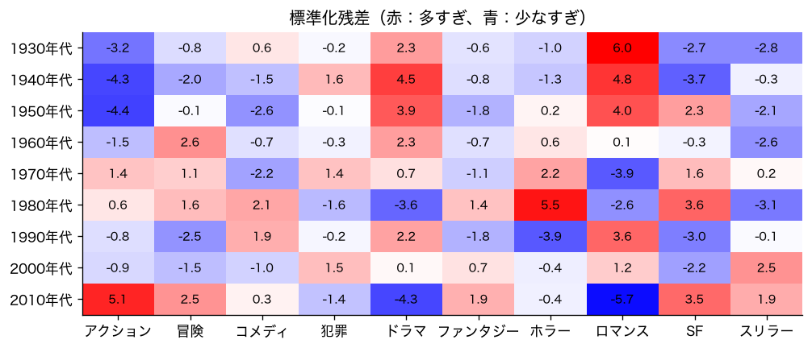

## お手本：大きいずれを並べる

3節 ③ 並べる●

```python
Rs = R.stack().sort_values()
print(Rs.tail(3).round(1))
```

```
年代    ジャンル
2010  Action     5.1
1980  Horror     5.5
1930  Romance    6.0
dtype: float64
```

- 1行目：表を1列に並べ（`stack`）、小さい順に並べ替える。2行目：大きい3つ

## カイ二乗統計量

3節 ④ カイ二乗●○○

- 標準化残差の2乗の和548.4は、表全体のずれの大きさ
- 教科書では、この値でカイ二乗検定をして、偶然かどうかを確かめる
- ところが、この表には、その検定の前提が当てはまらない

## 重要：重ねて数えた表

3節 ④ カイ二乗●●○

カイ二乗検定の式は、表の1つの数が1本の別の映画、という前提に立つ。重ねて数えた表では前提が崩れるので、p値は使わず、残差でずれを読む。

## 重要概念：残差で読む

3節 ④ カイ二乗●●●

区分×区分の表は、偏りがなければ何本か（期待度数）と比べ、ずれを標準化残差で読む。本数の大小に引きずられずに、どこが多すぎ・少なすぎかが分かる。

## TODO③：少なすぎのほうを見る

3節 ⑤ 少なすぎ●○

```python
# TODO: tail を head に替えて実行する
print(Rs.tail(3).round(1))
```

- 予想：いちばん少なすぎるマスはどこか

## ここまでで分かったこと

3節 ⑤ 少なすぎ●●

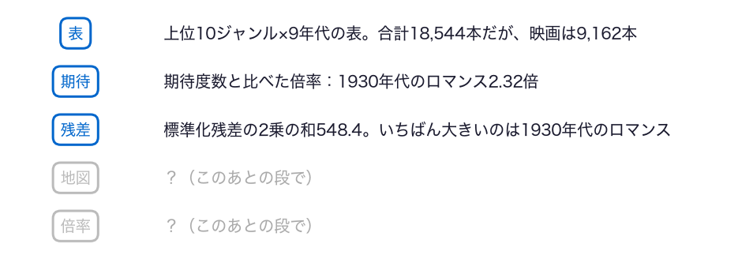

- まだ分からないのは、9×10のずれの表全体を、1枚にまとめて見られるか

## ノートへ：3節

3節 ⑥ ノートへ●

- 3節のセルを上から実行し、スライドと同じ数が出るか確かめる
- TODO③：予想を書く → `tail`を`head`に替えて実行 → 予想と比べる

動画の人は、ここで一時停止。

## 答え合わせ：TODO③

3節 ⑦ 答え合わせ●

```
年代    ジャンル
2010  Romance   -5.7
1950  Action    -4.4
2010  Drama     -4.3
dtype: float64
```

- いちばん少なすぎるのは、2010年代のロマンス（−5.7）。1950年代のアクション、2010年代のドラマが続く

# 4. 1枚の地図にできるか？

## 段4：地図に縮める

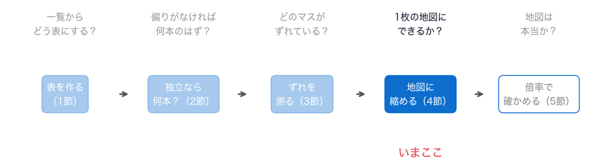

- 問い：9×10のずれの表を、1枚の地図にまとめられるか

## 前の段から

- 標準化残差で、どのマスが多すぎ・少なすぎかを読んだ
- 表は90マス。全体の形をつかむには、多すぎる
- 第11回の主成分分析と同じく、特異値分解で縮める

## 対応分析

4節 ① 対応分析●

- ずれ（標準化残差）の表を、特異値分解で少ない次元に縮める
- 行（年代）と列（ジャンル）を、同じ地図に置ける
- 近くにある年代とジャンルは、その組が多すぎる（正のずれ）

## お手本：残差の表を特異値分解

4節 ② SVD●○○

```python
U, s, Vt = np.linalg.svd(R.values, full_matrices=False)
print(U.shape, s.shape, Vt.shape)
print((s ** 2).sum().round(1))
print((s ** 2 / (s ** 2).sum())[:3].round(3))
```

```
(9, 9) (9,) (9, 10)
548.4
[0.673 0.166 0.082]
```

## 1行ずつ：残差の表を特異値分解

4節 ② SVD●●○

```python
U, s, Vt = np.linalg.svd(R.values, full_matrices=False)
print(U.shape, s.shape, Vt.shape)
print((s ** 2).sum().round(1))
print((s ** 2 / (s ** 2).sum())[:3].round(3))
```

- 1行目：9×10の残差の表を特異値分解（第11回）。`U`が年代の向き、`Vt`がジャンルの向き、`s`が特異値
- 3行目：特異値の2乗の和は548.4。カイ二乗統計量と同じ
- 4行目：次元ごとの寄与率。第1の次元だけで0.673

## 寄与率

4節 ② SVD●●●

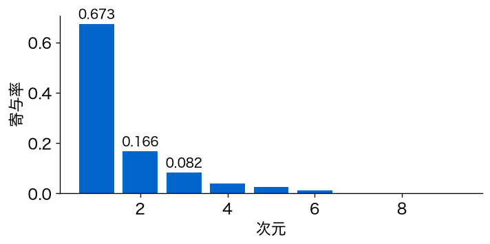

- 2つの次元で、ずれの84%を持つ。地図2枚目の次元までで、ほぼ読める

## お手本：地図の座標

4節 ③ 座標●○

```python
row_n = O.sum(axis=1).values.reshape(9, 1)
col_n = O.sum(axis=0).values.reshape(10, 1)
row_xy = U * s / np.sqrt(row_n)
col_xy = Vt.T * s / np.sqrt(col_n)
print(row_xy[:3, :2].round(2))
```

```
[[ 0.49 -0.09]
 [ 0.5  -0.  ]
 [ 0.27 -0.23]]
```

## 1行ずつ：地図の座標

4節 ③ 座標●●

```python
row_n = O.sum(axis=1).values.reshape(9, 1)
col_n = O.sum(axis=0).values.reshape(10, 1)
row_xy = U * s / np.sqrt(row_n)
col_xy = Vt.T * s / np.sqrt(col_n)
print(row_xy[:3, :2].round(2))
```

- 1・2行目：年代の合計とジャンルの合計を、縦1列の形にする（`reshape`、第11回）
- 3・4行目：向き×特異値を、合計の平方根で割る。本数の多い行や列が、原点から離れすぎないようにする
- 5行目：先頭3年代の、第1・第2の次元の座標

## お手本：地図を描く

4節 ④ 地図●○

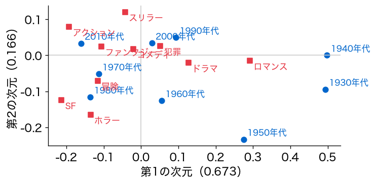

```python
dy = 1
plt.figure(figsize=(10, 7))
plt.scatter(row_xy[:, 0], row_xy[:, dy])
for i in range(9):
    plt.text(row_xy[i, 0], row_xy[i, dy], O.index[i])
plt.scatter(col_xy[:, 0], col_xy[:, dy], marker='s')
for j in range(10):
    plt.text(col_xy[j, 0], col_xy[j, dy], O.columns[j])
plt.axhline(0, color='gray')
plt.axvline(0, color='gray')
plt.show()
```

## 1行ずつ：地図を描く

4節 ④ 地図●●

```python
dy = 1
plt.figure(figsize=(10, 7))
plt.scatter(row_xy[:, 0], row_xy[:, dy])
for i in range(9):
    plt.text(row_xy[i, 0], row_xy[i, dy], O.index[i])
plt.scatter(col_xy[:, 0], col_xy[:, dy], marker='s')
for j in range(10):
    plt.text(col_xy[j, 0], col_xy[j, dy], O.columns[j])
plt.axhline(0, color='gray')
plt.axvline(0, color='gray')
plt.show()
```

- 1・2行目：縦軸に使う次元の番号（1は第2の次元）を決め、図を大きくする
- 3〜5行目：年代を点で打ち、名前を書く。6〜8行目：ジャンルを四角で打ち、名前を書く
- 9〜11行目：原点を通る線。スライドの図は、ジャンルを日本語の名前にした

## 横軸は、古い↔︎新しい

4節 ⑤ 読む●○○

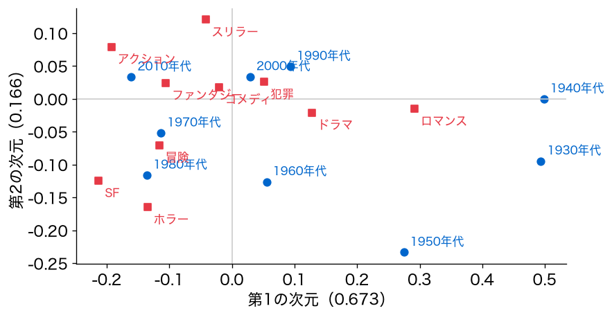

- 右に1930〜50年代とロマンス・ドラマ、左に2010年代とSF・アクション・ホラー

## えっ、2000年代が真ん中に

4節 ⑤ 読む●●○

```python
print(O.sum(axis=1).tolist())
```

```
[242, 334, 454, 697, 916, 2224, 4147, 5809, 3721]
```

- 本数がいちばん多い2000年代（5,809）は、原点の近く
- 原点は「全体の平均の割合」。2000年代は本数が多いので、全体の割合にいちばん近い
- 地図は、本数ではなく、割合の偏りを表す

## 重要：地図の近さは、割合の偏り

4節 ⑤ 読む●●●

対応分析の地図で原点から遠いほど、全体の割合からずれている。年代とジャンルが同じ向きにあれば、その組が多すぎる。本数の多さは、地図には出ない。

## TODO④：縦軸を第3の次元に

4節 ⑥ 次元●○

```python
# TODO: 1 を 2 に替えて実行する
dy = 1
plt.figure(figsize=(10, 7))
plt.scatter(row_xy[:, 0], row_xy[:, dy])
for i in range(9):
    plt.text(row_xy[i, 0], row_xy[i, dy], O.index[i])
plt.scatter(col_xy[:, 0], col_xy[:, dy], marker='s')
for j in range(10):
    plt.text(col_xy[j, 0], col_xy[j, dy], O.columns[j])
plt.axhline(0, color='gray')
plt.axvline(0, color='gray')
plt.show()
```

- 予想：第3の次元（寄与率0.082）では、どの年代が離れるか

## ここまでで分かったこと

4節 ⑥ 次元●●

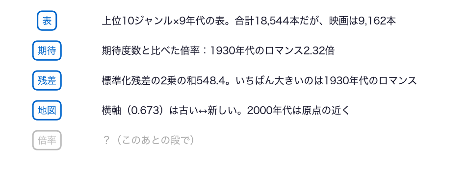

- まだ分からないのは、地図で見えたことが、表の数でも本当か

## ノートへ：4節

4節 ⑦ ノートへ●

- 4節のセルを上から実行し、スライドと同じ数が出るか確かめる
- TODO④：予想を書く → `1`を`2`に替えて実行 → 予想と比べる

動画の人は、ここで一時停止。

## 答え合わせ：TODO④

4節 ⑧ 答え合わせ●

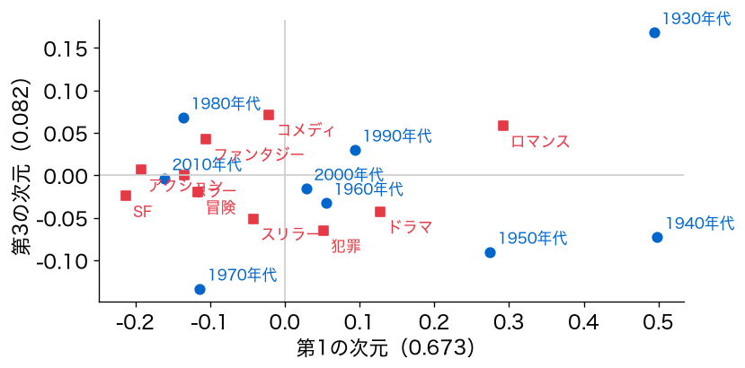

- 第3の次元では、1930年代が上に、1970年代が下に離れる。寄与率は0.082と小さく、細かい違い

# 5. 地図は本当か？

## 段5：倍率で確かめる

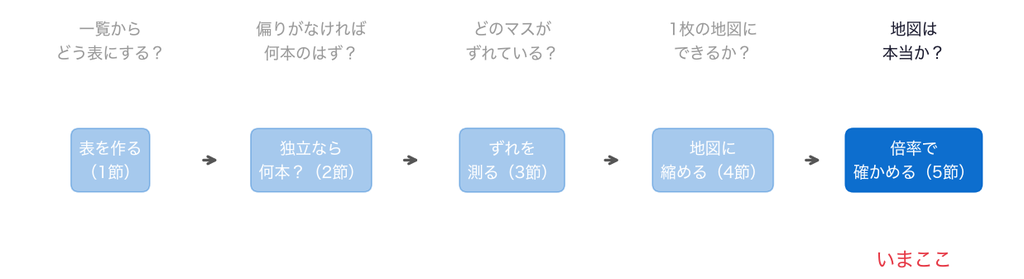

- 問い：地図で近く見えた年代とジャンルは、表の数でも本当に多すぎるか

## 前の段から

- 残差の表を特異値分解で縮め、年代とジャンルを1枚の地図に置いた
- 横軸は古い↔︎新しい。本数の多い2000年代は真ん中
- 地図は縮めた近似。最後は、表の数（倍率）で確かめる

## お手本：1つの年代の倍率

5節 ① 1年代●○

```python
print(ratio.loc[1930].sort_values(ascending=False).round(2))
```

```
ジャンル
Romance      2.32
Drama        1.31
Comedy       1.09
Crime        0.96
Fantasy      0.80
Adventure    0.79
Horror       0.71
Thriller     0.45
Action       0.34
Sci-Fi       0.24
Name: 1930, dtype: float64
```

- 1930年代の倍率を、大きい順に並べた。ロマンス・ドラマが上、SF・アクションが下

## 地図と倍率は合っている

5節 ① 1年代●●

- 1930年代は、地図でロマンス・ドラマの近くにいた
- 倍率でも、ロマンス2.32倍、ドラマ1.31倍
- SF（0.24倍）・アクション（0.34倍）は、地図で反対側にいた

## 年代ごとに1文にする

5節 ② 1文●○○○

- 9つの年代すべてで、倍率の上位3ジャンルを並べたい
- 年代ごとに同じ手順をくり返すので、`for`で回す
- ジャンルの名前のリストを、「、」でつないで1つの文字列にする（`join`）

## join：最小の例

5節 ② 1文●●○○

```python
names = ['Romance', 'Drama', 'Comedy']
print('、'.join(names))
print('1930年代：' + '、'.join(names))
```

```
Romance、Drama、Comedy
1930年代：Romance、Drama、Comedy
```

- `'、'.join(リスト)`は、リストの文字列を「、」でつなぐ。`split`の逆。`+`で文字列どうしをつなぐ

## お手本：年代ごとの1文

5節 ② 1文●●●○

```python
for d in ratio.index:
    top3 = ratio.loc[d].sort_values(ascending=False).index[:3]
    print(str(d) + '年代：' + '、'.join(top3))
```

```
1930年代：Romance、Drama、Comedy
1940年代：Romance、Drama、Crime
1950年代：Romance、Sci-Fi、Drama
1960年代：Adventure、Drama、Horror
1970年代：Horror、Sci-Fi、Crime
1980年代：Horror、Sci-Fi、Fantasy
1990年代：Romance、Drama、Comedy
2000年代：Thriller、Crime、Romance
2010年代：Action、Sci-Fi、Adventure
```

## 1行ずつ：年代ごとの1文

5節 ② 1文●●●●

```python
for d in ratio.index:
    top3 = ratio.loc[d].sort_values(ascending=False).index[:3]
    print(str(d) + '年代：' + '、'.join(top3))
```

- 1行目：年代を1つずつ取る
- 2行目：その年代の倍率を大きい順に並べ、上位3つのジャンルの名前を取る
- 3行目：年代を文字にし（`str`）、ジャンルを「、」でつないで、1文にする

## 時代の流れ

5節 ③ 流れ●○

- 1930〜50年代：ロマンス・ドラマ
- 1970〜80年代：ホラー・SF
- 2010年代：アクション・SF・冒険。地図の横軸の、右から左への流れと同じ

## 重要：地図は表で確かめる

5節 ③ 流れ●●

対応分析の地図は、ずれの表を縮めた近似。地図で近く見えた組は、倍率や残差の表に戻って、数で確かめてから言う。

## TODO⑤：上位の数を替える

5節 ④ 上位●○

```python
# TODO: 3 を 5 に替えて実行する
for d in ratio.index:
    top = ratio.loc[d].sort_values(ascending=False).index[:3]
    print(str(d) + '年代：' + '、'.join(top))
```

- 予想：上位5つにすると、1990・2000年代の1文はどうなるか

## ここまでで分かったこと

5節 ④ 上位●●

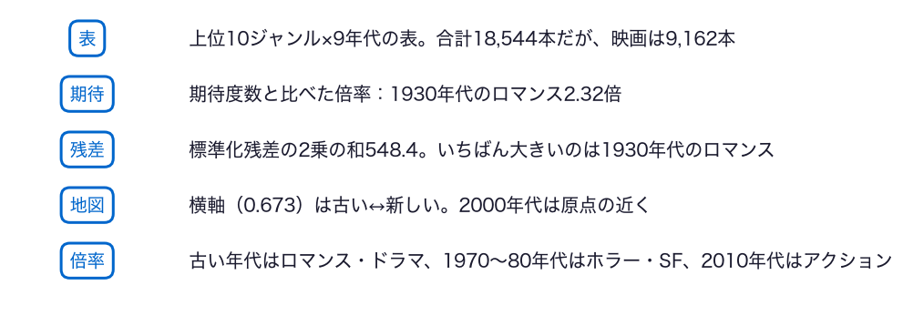

- 5つの段がそろい、今日の問いに答えられる

## ノートへ：5節

5節 ⑤ ノートへ●

- 5節のセルを上から実行し、スライドと同じ数が出るか確かめる
- TODO⑤：予想を書く → `3`を`5`に替えて実行 → 予想と比べる

動画の人は、ここで一時停止。

## 答え合わせ：TODO⑤

5節 ⑥ 答え合わせ●

```
1990年代：Romance、Drama、Comedy、Thriller、Crime [1.19 1.07 1.06 0.99 0.99]
2000年代：Thriller、Crime、Romance、Fantasy、Drama [1.1  1.08 1.05 1.04 1.  ]
```

- 1990・2000年代は、上位5つでも倍率が1.0〜1.2くらい。どのジャンルも、ほぼ全体の割合どおり
- 地図で原点の近くにいたのと合う

## 答え：時代とともに移る

5節 ⑦ 答え●

- 古い年代はロマンス・ドラマ、1970〜80年代はホラー・SF、2010年代はアクション・SF
- 地図の横軸（寄与率0.673）は、この時代の流れ。本数の多い1990・2000年代は真ん中
- 区分×区分の表は、期待度数と比べた残差と倍率で読んだ

## まだ言えないこと

5節 ⑧ まだ言えないこと●

- ずれが偶然でないか。重ねて数えた表なので、カイ二乗検定の式は使えない
- MovieLensの一覧は、評価サイトの利用者が見た映画。作られた映画のすべてではない
- ジャンルの付け方は、サイトの決め方による

# まとめ

## 今日の道筋を振り返る

⑨ 振り返る●○○○

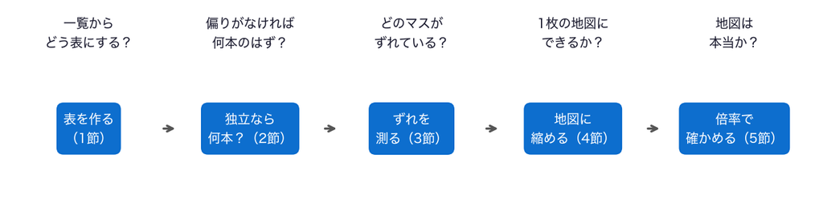

- 一覧から表を作り、期待度数と比べ、残差でずれを測り、地図に縮め、倍率で確かめた

## 今日持ち帰る1文

⑨ 振り返る●●○○

区分×区分の表は、偏りがなければ何本か（期待度数）と比べ、標準化残差でずれを読む。ずれの表を特異値分解すると、行と列を1枚の地図に置ける。地図で見えたことは、倍率の表で確かめる。

## 今日の重要概念

⑨ 振り返る●●●○

統計：区分×区分の表は、期待度数と比べ、ずれを標準化残差で読む。本数の大小に引きずられずに、どこが多すぎ・少なすぎかが分かる。

Python：1つのマスに詰めた複数の値は、区切りの文字で分け（split）、1つずつを1行にする（explode）。

## 今日の要点

⑨ 振り返る●●●●

- 表の合計が、数えたもの（映画）の数と合うかを確かめる。重ねて数えていたら、検定の式は使えない
- 対応分析の地図の近さは、本数ではなく割合の偏り
- 地図で見えたことは、倍率と残差の表で確かめてから言う

## レポートなら、こう書く①

10 レポートなら●○

- データ：MovieLensの映画の一覧から、1930〜2010年代の9,682本。ジャンルを分けて、上位10ジャンル×9年代の表にした
- 注意：表の合計は18,544で、映画は9,162本。重ねて数えているので検定の式は使わず、残差で読んだ
- ずれ：1930年代のロマンスは期待の2.32倍（残差6.0）、2010年代のロマンスは残差−5.7

## レポートなら、こう書く②

10 レポートなら●●

- 地図：残差の表を特異値分解。第1の次元（寄与率0.673）は古い↔︎新しい
- 驚き：本数がいちばん多い2000年代は原点の近く。地図は本数でなく割合の偏りを表す
- 限界：評価サイトの利用者が見た映画だけ。ジャンルの付け方もサイトによる

## 課題の出し方

11 このあと●○○

- 今日の重要概念は、統計の「期待と比べて、残差で読む」と、Pythonの「文字列を分ける」
- 2つを1枚ずつ絵にし、2枚をLACSに提出（＝出席。期限なし）
- 手描きの写真でも、描画アプリでもよい。上手でなくてよい

## 次回の問い

11 このあと●●○

- 今日の表は、年代とジャンルの組を数えたもの
- では、もの同士のつながり（誰と誰が、どこからどこへ）そのものは、どう分析すればよいか

## このあと：課題へ

11 このあと●●●

- ノートの最後の「課題（提出）」を開く
- 絵を描き終えたら、このあとの「解答」で、絵の例と見比べる

# ここから先は解答

## 課題のあとで見る

- ここから先は、課題の絵を描き終えてから見る
- 絵の例を2つ見せる。上手さではなく、考えが伝わるかを見比べる

## 絵の例：期待と比べて、残差で読む

- クラスごとの、好きな給食の投票
- 大きいクラスは、どの給食も票が多い。票の数だけでは、クラスの好みは分からない
- 「クラスの人数 × 全校での人気」で、偏りがなければ何票かを出し、それより多い・少ないで読む

## 絵の例：文字列を分ける

- 1枚の紙に「りんご・みかん・ぶどう」と書いた買い物メモ
- 「・」で切り分けて、1つずつの紙にする
- 3枚になった紙を、果物ごとに数える

# 発展（任意）

## 区分が3つ以上なら？

- 今日は、年代とジャンルの2つの区分の表だった
- 区分が3つ以上（たとえば第9回のペンギンの種・島・性別）でも、同じ考えで地図にできる
- 1羽を、区分の値ごとの0と1の列にした表を、同じ特異値分解で縮める（多重対応分析）

## お手本：0と1の表

```python
# データはこのリポジトリから読み込む
DATA_DIR = ('https://raw.githubusercontent.com/k0heiun0/'
            'applied_exercise_preview/main/shared/data')
pen = pd.read_csv(f'{DATA_DIR}/penguins.csv').dropna(subset=['sex'])
D = pd.get_dummies(pen[['species', 'island', 'sex']],
                   prefix='', prefix_sep='').astype(int)
print(D.shape)
D.head(3)
```

```
(333, 8)
```

|  | アデリー | ジェンツー | ヒゲ | トージャーセン | ドリーム | ビスコー | オス | メス |
| --- | --- | --- | --- | --- | --- | --- | --- | --- |
| 0 | 1 | 0 | 0 | 1 | 0 | 0 | 1 | 0 |
| 1 | 1 | 0 | 0 | 1 | 0 | 0 | 0 | 1 |
| 2 | 1 | 0 | 0 | 1 | 0 | 0 | 0 | 1 |

## 1行ずつ：0と1の表

```python
# データはこのリポジトリから読み込む
DATA_DIR = ('https://raw.githubusercontent.com/k0heiun0/'
            'applied_exercise_preview/main/shared/data')
pen = pd.read_csv(f'{DATA_DIR}/penguins.csv').dropna(subset=['sex'])
D = pd.get_dummies(pen[['species', 'island', 'sex']],
                   prefix='', prefix_sep='').astype(int)
print(D.shape)
D.head(3)
```

- `DATA_DIR`と`pd.read_csv`の行：第9回のペンギンを読み、性別が欠測の羽を外す
- `get_dummies`の行：種・島・性別の値ごとに、当てはまれば1、そうでなければ0の列を作る（`get_dummies`）
- `print`と`head`の行：333羽×8列（種3・島3・性別2）

## ペンギンの区分の地図

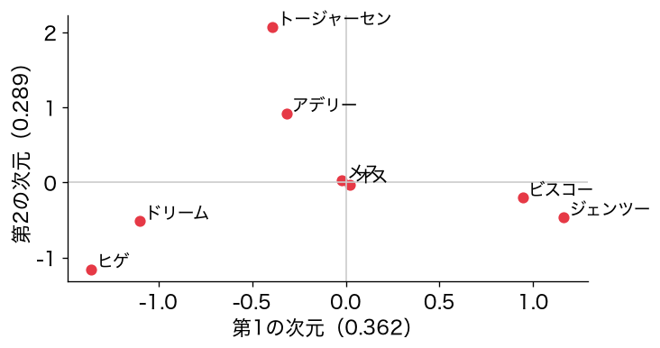

## おわり

- お疲れさまでした